##### **CUNY SPS BRIDGE R Assignment 3 (Final Project)**

##### **Name: Chinedu Onyeka; Date: August 8th, 2021**

##### **Meaningful Question: I want to use the test data from California Schools to find out if students from higher income households do better in Math and Reading Tests**

##### Problem 1: 1. Data Exploration: This should include summary statistics, means, medians, quartiles, or any other relevant information about the data set. Please include some conclusions in the R

```r
#Read the data
url = "https://github.com/chinedu2301/CUNY-SPS-Bridge/raw/main/CASchools.csv"
data <- read.table(file = url, header = TRUE, sep = ",")
head(data)
```

```
##   X district                          school  county grades students teachers
## 1 1    75119              Sunol Glen Unified Alameda  KK-08      195    10.90
## 2 2    61499            Manzanita Elementary   Butte  KK-08      240    11.15
## 3 3    61549     Thermalito Union Elementary   Butte  KK-08     1550    82.90
## 4 4    61457 Golden Feather Union Elementary   Butte  KK-08      243    14.00
## 5 5    61523        Palermo Union Elementary   Butte  KK-08     1335    71.50
## 6 6    62042         Burrel Union Elementary  Fresno  KK-08      137     6.40
##   calworks   lunch computer expenditure    income   english  read  math
## 1   0.5102  2.0408       67    6384.911 22.690001  0.000000 691.6 690.0
## 2  15.4167 47.9167      101    5099.381  9.824000  4.583333 660.5 661.9
## 3  55.0323 76.3226      169    5501.955  8.978000 30.000002 636.3 650.9
## 4  36.4754 77.0492       85    7101.831  8.978000  0.000000 651.9 643.5
## 5  33.1086 78.4270      171    5235.988  9.080333 13.857677 641.8 639.9
## 6  12.3188 86.9565       25    5580.147 10.415000 12.408759 605.7 605.4
```

```r
summary(data) #summary of the data to view descriptive statistics of the data
```

```
##        X            district        school             county
##  Min.   :  1.0   Min.   :61382   Length:420         Length:420
##  1st Qu.:105.8   1st Qu.:64308   Class :character   Class :character
##  Median :210.5   Median :67761   Mode  :character   Mode  :character
##  Mean   :210.5   Mean   :67473
##  3rd Qu.:315.2   3rd Qu.:70419
##  Max.   :420.0   Max.   :75440
##     grades             students          teachers          calworks
##  Length:420         Min.   :   81.0   Min.   :   4.85   Min.   : 0.000
##  Class :character   1st Qu.:  379.0   1st Qu.:  19.66   1st Qu.: 4.395
##  Mode  :character   Median :  950.5   Median :  48.56   Median :10.520
##                     Mean   : 2628.8   Mean   : 129.07   Mean   :13.246
##                     3rd Qu.: 3008.0   3rd Qu.: 146.35   3rd Qu.:18.981
##                     Max.   :27176.0   Max.   :1429.00   Max.   :78.994
##      lunch           computer       expenditure       income
##  Min.   :  0.00   Min.   :   0.0   Min.   :3926   Min.   : 5.335
##  1st Qu.: 23.28   1st Qu.:  46.0   1st Qu.:4906   1st Qu.:10.639
##  Median : 41.75   Median : 117.5   Median :5215   Median :13.728
##  Mean   : 44.71   Mean   : 303.4   Mean   :5312   Mean   :15.317
##  3rd Qu.: 66.86   3rd Qu.: 375.2   3rd Qu.:5601   3rd Qu.:17.629
##  Max.   :100.00   Max.   :3324.0   Max.   :7712   Max.   :55.328
##     english            read            math
##  Min.   : 0.000   Min.   :604.5   Min.   :605.4
##  1st Qu.: 1.941   1st Qu.:640.4   1st Qu.:639.4
##  Median : 8.778   Median :655.8   Median :652.5
##  Mean   :15.768   Mean   :655.0   Mean   :653.3
##  3rd Qu.:22.970   3rd Qu.:668.7   3rd Qu.:665.9
##  Max.   :85.540   Max.   :704.0   Max.   :709.5
```

```r
str(data)
```

```
## 'data.frame':    420 obs. of  15 variables:
##  $ X          : int  1 2 3 4 5 6 7 8 9 10 ...
##  $ district   : int  75119 61499 61549 61457 61523 62042 68536 63834 62331 67306 ...
##  $ school     : chr  "Sunol Glen Unified" "Manzanita Elementary" "Thermalito Union Elementary" "Golden Feather Union Elementary" ...
##  $ county     : chr  "Alameda" "Butte" "Butte" "Butte" ...
##  $ grades     : chr  "KK-08" "KK-08" "KK-08" "KK-08" ...
##  $ students   : int  195 240 1550 243 1335 137 195 888 379 2247 ...
##  $ teachers   : num  10.9 11.1 82.9 14 71.5 ...
##  $ calworks   : num  0.51 15.42 55.03 36.48 33.11 ...
##  $ lunch      : num  2.04 47.92 76.32 77.05 78.43 ...
##  $ computer   : int  67 101 169 85 171 25 28 66 35 0 ...
##  $ expenditure: num  6385 5099 5502 7102 5236 ...
##  $ income     : num  22.69 9.82 8.98 8.98 9.08 ...
##  $ english    : num  0 4.58 30 0 13.86 ...
##  $ read       : num  692 660 636 652 642 ...
##  $ math       : num  690 662 651 644 640 ...
```

##### **The mean math score is 653.3 and the maximum math score is 709.5. The mean income is 15.317 while the maximum income is 55.328.**

##### Problem 2: Data wrangling: Please perform some basic transformations. They will need to make sense but could include column renaming, creating a subset of the data, replacing values, or creating new columns with derived data (for example – if it makes sense you could sum two columns together)

```r
#Install and or load relevant libraries for data wrangling
library(tidyverse)
library(ggthemes)
var <- c("school","grades","income", "teachers", "students","read", "math")
data <- data %>% as_tibble() %>% select(all_of(var)) %>% arrange(desc(math, read, english)) %>% mutate(teacher_stu = teachers/students)
#I selected the relevant columns for my analysis
head(data)
```

```
## # A tibble: 6 x 8
##   school                 grades income teachers students  read  math teacher_stu
##   <chr>                  <chr>   <dbl>    <dbl>    <int> <dbl> <dbl>       <dbl>
## 1 Los Altos Elementary   KK-08    41.7    208.      3724  704   710.      0.0560
## 2 Las Lomitas Elementary KK-08    28.7     59.7      984  701.  708.      0.0607
## 3 Cold Spring Elementary KK-06    43.2     12.3      220  693.  704.      0.0560
## 4 Saratoga Union Elemen~ KK-08    40.4    124.      2341  699.  702.      0.0530
## 5 Hillsborough City Ele~ KK-08    35.8     87.1     1318  695.  701.      0.0661
## 6 Portola Valley Elemen~ KK-08    50.7     44.6      687  698.  700.      0.0649
```

###### *The school with the highest Math Score is the Los Altos Elementary*

```r
any(is.na(data)) #Check for missing values
```

```
## [1] FALSE
```

###### *There are no missing values in the data set*

##### Problem 3: Graphics: Please make sure to display at least one scatter plot, box plot and histogram. Don’t be limited to this. Please explore the many other options in R packages such as ggplot2.

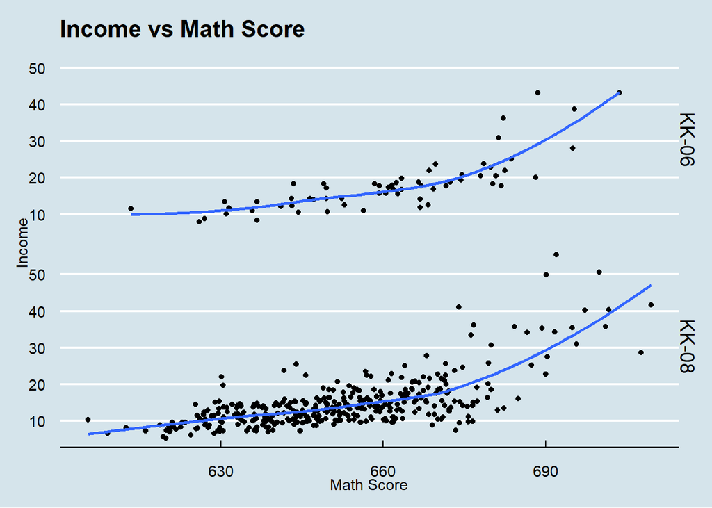

```r
#Plot a graph of Income vs Math Score
pl_Income_Math <- ggplot(data, aes(x = math, y = income)) + geom_point() + stat_smooth(se=FALSE) + labs(x="Math Score", y= "Income", title = "Income vs Math Score") + facet_grid(rows = "grades") + theme_economist()
print(pl_Income_Math)
```

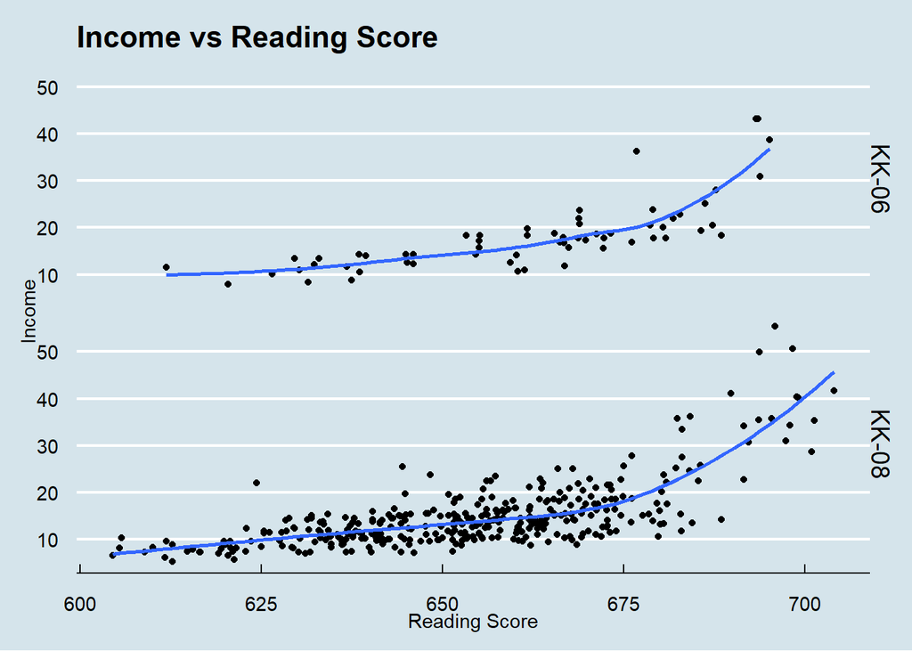

```r
#Plot a graph of Income vs Reading Score
pl_Income_Read <- ggplot(data, aes(x =read, y = income)) + geom_point() + stat_smooth(se=FALSE) + labs(x="Reading Score", y= "Income", title = "Income vs Reading Score") + facet_grid(rows = "grades")  + theme_economist()
print(pl_Income_Read)
```

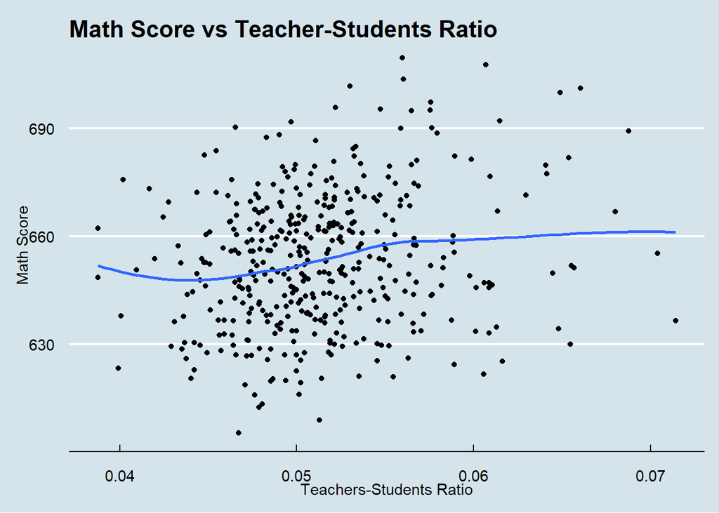

```r
#Plot a graph of Math Score vs Teacher-Student Ratio
pl_Math_TSR <- ggplot(data, aes(x =teacher_stu, y = math)) + geom_point() + stat_smooth(se=FALSE)+ labs(x="Teachers-Students Ratio", y= "Math Score", title = "Math Score vs Teacher-Students Ratio")+theme_economist()
print(pl_Math_TSR)
```

```r
#Correlation between Income and Math Score
cor_inc_Math <- cor.test(data$math, data$income)
print("Correlation between Income and Math Scores")
```

```
## [1] "Correlation between Income and Math Scores"
```

```r
print(cor_inc_Math)
```

```
##
##  Pearson's product-moment correlation
##
## data:  data$math and data$income
## t = 20.006, df = 418, p-value < 2.2e-16
## alternative hypothesis: true correlation is not equal to 0
## 95 percent confidence interval:
##  0.6470117 0.7452127
## sample estimates:
##       cor
## 0.6993981
```

```r
cor_inc_Read <- cor_inc_Read <- cor.test(data$read, data$income)
print("Correlation between Income and Reading Scores")
```

```
## [1] "Correlation between Income and Reading Scores"
```

```r
print(cor_inc_Read)
```

```
##
##  Pearson's product-moment correlation
##
## data:  data$read and data$income
## t = 19.918, df = 418, p-value < 2.2e-16
## alternative hypothesis: true correlation is not equal to 0
## 95 percent confidence interval:
##  0.6452147 0.7438378
## sample estimates:
##       cor
## 0.6978189
```

##### Problem 4: Meaningful question for analysis: Please state at the beginning a meaningful question for analysis. Use the first three steps and anything else that would be helpful to answer the question you are posing from the data set you chose. Please write a brief conclusion paragraph in R markdown at the end.

##### **Answer: *Conclusion- It can be clearly seen from the graphs that the math and reading scores for California students generally increases for both grades KK-06 and KK-08 as the income level of the household increases. Also, the correlation between Income and Math Scores as well as between Income and Reading Scores of CA School students is about 0.7 which indicates a strong positive correlation between each of the two variables. Hence, I can conclude that students from high income homes have more chances of having a higher Math and Reading scores than their counterparts from low income homes according to data from CA Schools***

##### Problem 5: BONUS – place the original .csv in a github file and have R read from the link. This will be a very useful skill as you progress in your data science education and career.

##### **Answer: *See problem 1***